# Study 2 Results

Dan Wall

July 28, 2017

# 1 Main Text Results

```r
# Join with the avoidant transition dataframe
study2_payne <- study2_payne %>%
  mutate(serial = as.numeric(serial)) %>%
  left_join(., study2_nothresh_joy,
            by = c("serial", "id"))

study2_payne <- study2_payne %>%
  mutate(compliance_ind = joy_ind * -1,
         compliance_fac  = ifelse(compliance_ind == -1, "neg_1",
                                                  ifelse(compliance_ind == 1, "pos_1",
                                                         "other")) %>%
           factor(levels = c("neg_1", "other", "pos_1")),
         compliance_fac_naother = ifelse(is.na(compliance_fac), "other",
                                         as.character(compliance_fac)) %>%
           factor(levels = c("neg_1", "other", "pos_1")),
         Easy = ifelse(hard == "hardhoriz", "Integrative",
                       ifelse(hard == "hardvert", "Comparative", NA)) %>%
           factor,
         total_time_ms_log10 = log10(total_time_ms + 1))



# Ensure we have the dataframe contrast coded
contrasts(study2_payne$accel_delay)<-c(-1,1)
colnames(contrasts(study2_payne$accel_delay))<-c("Delay")
contrasts(study2_payne$Easy)<-c(-1,1)
colnames(contrasts(study2_payne$Easy))<-c("Integrative")
```

## 1.1 Payne Index Manipulation Check

Participants in the Easy Comparative (M=-0.85) condition had lower Payne Indices than those in the Easy Integrative condition (M=0.87), ??=0.86, s.e.=0.01, p<.001, verifying that the manipulation changed search behavior in the expected direction.

```r
study2_payne %>%
  group_by(serial, Easy) %>%
  summarise(mean_pi = mean(payne_ind, na.rm = TRUE)) %>%
  group_by(Easy) %>%
  summarise(mean_tot_pi = mean(mean_pi, na.rm = TRUE),
            sd_tot_pit = sd(mean_pi, na.rm = TRUE))
```

```
## # A tibble: 2 x 3
##          Easy mean_tot_pi sd_tot_pit
##        <fctr>       <dbl>      <dbl>
## 1 Comparative  -0.8531352  0.1990981
## 2 Integrative   0.8705877  0.1540540
```

```r
pi_ht_lmer <- lmer(payne_ind ~ Easy + (1|serial) , study2_payne)
summary(pi_ht_lmer)
```

```
## Linear mixed model fit by REML ['lmerMod']
## Formula: payne_ind ~ Easy + (1 | serial)
##    Data: study2_payne
##
## REML criterion at convergence: 6313
##
## Scaled residuals:
##     Min      1Q  Median      3Q     Max
## -4.6594 -0.2516 -0.0556  0.2068  4.6625
##
## Random effects:
##  Groups   Name        Variance Std.Dev.
##  serial   (Intercept) 0.02545  0.1595
##  Residual             0.17045  0.4129
## Number of obs: 5588, groups:  serial, 207
##
## Fixed effects:
##                 Estimate Std. Error t value
## (Intercept)     0.007682   0.012482    0.62
## EasyIntegrative 0.861300   0.012482   69.00
##
## Correlation of Fixed Effects:
##             (Intr)
## EasyIntgrtv 0.052
```

```r
Anova(pi_ht_lmer, type = 3)
```

```
## Analysis of Deviance Table (Type III Wald chisquare tests)
##
## Response: payne_ind
##                 Chisq Df Pr(>Chisq)
## (Intercept)    0.3787  1     0.5383
## Easy        4761.1712  1     <2e-16 ***
## ---
## Signif. codes:  0 '***' 0.001 '**' 0.01 '*' 0.05 '.' 0.1 ' ' 1
```

## 1.2 Choice Model Summary

There was a significant effect of search condition, ??=-0.23, s.e.=0.10, p=.027, with participants in the Easy Comparative condition exhibiting greater patience than those in the Easy Integrative condition. Participants were also more patient when options were framed as decisions to accelerate rather than delay consumption, ??=-0.06, s.e.=0.03, p=.044. The interaction between the two factors was not significant, p = .761.

```r
# We are using the hard transition Payne Index data frame
# We also have only a varying intercept for serial
ch_glmer1ht <- glmer(choice ~ accel_delay * Easy + (1 | serial),
                   study2_payne, family = binomial)

summary(ch_glmer1ht)
```

```
## Generalized linear mixed model fit by maximum likelihood (Laplace
##   Approximation) [glmerMod]
##  Family: binomial  ( logit )
## Formula: choice ~ accel_delay * Easy + (1 | serial)
##    Data: study2_payne
##
##      AIC      BIC   logLik deviance df.resid
##   8225.9   8260.3  -4107.9   8215.9     7170
##
## Scaled residuals:
##     Min      1Q  Median      3Q     Max
## -3.7751 -0.7456 -0.3006  0.8342  4.1681
##
## Random effects:
##  Groups Name        Variance Std.Dev.
##  serial (Intercept) 1.982    1.408
## Number of obs: 7175, groups:  serial, 207
##
## Fixed effects:
##                                   Estimate Std. Error z value Pr(>|z|)
## (Intercept)                      -0.531790   0.103148  -5.156 2.53e-07 ***
## accel_delayDelay                 -0.056243   0.027879  -2.017   0.0437 *
## EasyIntegrative                  -0.227475   0.102989  -2.209   0.0272 *
## accel_delayDelay:EasyIntegrative -0.008464   0.027879  -0.304   0.7614
## ---
## Signif. codes:  0 '***' 0.001 '**' 0.01 '*' 0.05 '.' 0.1 ' ' 1
##
## Correlation of Fixed Effects:
##             (Intr) accl_D EsyInt
## accl_dlyDly -0.003
## EasyIntgrtv  0.052  0.000
## accl_dlD:EI  0.000  0.058 -0.003
```

```r
Anova(ch_glmer1ht, type = 3)
```

```
## Analysis of Deviance Table (Type III Wald chisquare tests)
##
## Response: choice
##                    Chisq Df Pr(>Chisq)
## (Intercept)      26.5803  1  2.528e-07 ***
## accel_delay       4.0699  1    0.04365 *
## Easy              4.8784  1    0.02719 *
## accel_delay:Easy  0.0922  1    0.76144
## ---
## Signif. codes:  0 '***' 0.001 '**' 0.01 '*' 0.05 '.' 0.1 ' ' 1
```

## 1.3 Effect Plot

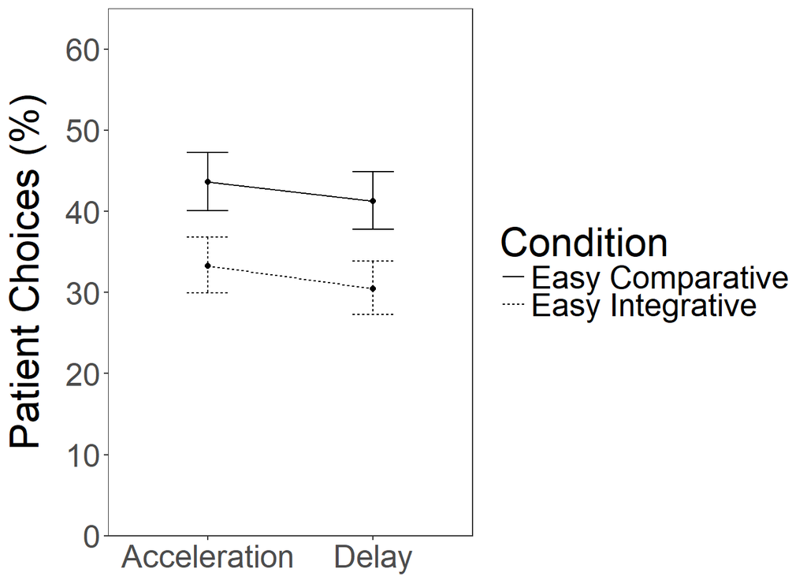

```r
ch_mlacde02_eff <- Effect(c("accel_delay", "Easy"),
                          ch_glmer1ht) %>%
  as.data.frame() %>%
  mutate(log_odds = log(fit/(1-fit)),
         se_lower_lo = log_odds - se,
         se_upper_lo = log_odds  + se,
         se_lower_pr = invlogit(se_lower_lo),
         se_upper_pr = invlogit(se_upper_lo),
         fit = fit * 100,
         se_lower_pr = se_lower_pr * 100,
         se_upper_pr = se_upper_pr * 100)


(ch_mlacde02_eff_plot <- ggplot(ch_mlacde02_eff,
                           aes(x = accel_delay, y = fit, group = Easy, linetype = Easy)) +
  geom_point() +
  geom_line() +
  geom_errorbar(aes(ymin = se_lower_pr, ymax = se_upper_pr, width=0.25)) +
  xlab(NULL)+
  ylab("Patient Choices (%)") +
  scale_x_discrete(labels = c("Acceleration", "Delay")) +
  scale_y_continuous(limits = c(0, 65), expand = c(0,0), breaks = seq(0, 60, by = 10)) +
  scale_linetype_discrete(guide = guide_legend(title = "Condition"), labels = c("Easy Comparative", "Easy Integrative")) +
  theme_bw() +
  theme(panel.grid.major = element_blank(),
        panel.grid.minor = element_blank(),
        legend.key = element_blank(),
        text = element_text(size=25),
        axis.title.y=element_text(margin=margin(0,15,0,0))))
```

```r
# tiff("/Users/Dan/Dropbox/MLWeb/Paper Figures/Figure5.tif", res = 300, width = 2000, height = 2400)
# ch_mlacde02_eff_plot # Make plot
# dev.off()
```

## 1.4 Only Consistent Trial analysis

We also performed analyses that restricted our analyses to trials in which participants did not use diagonal transitions to avoid the delay (see SI Appendix, Supplemental Results; Fig. 4, right panel). In these data, there were still significant effects of search condition, ??=-0.36, s.e.=0.10, p<.001, and option framing, ??=-0.17, s.e.=0.04, p<.001. Importantly, the interaction between search condition and framing was significant, ??=0.15, s.e.=0.04, p<.001. In alignment with Experiment 1, participants in the Easy Comparative condition exhibited a significant effect of framing, ??=.65, s.e.=0.12, p<.001, while those in the Easy Integrative condition did not, ??=0.04, s.e.=0.10, p=.702.

```r
ch_compl_pos1_glmer4 <- glmer(choice ~ accel_delay * Easy + (1 | serial),
                         study2_payne %>%
                           filter(compliance_fac_naother == "pos_1"), family = binomial)

summary(ch_compl_pos1_glmer4)
```

```
## Generalized linear mixed model fit by maximum likelihood (Laplace
##   Approximation) [glmerMod]
##  Family: binomial  ( logit )
## Formula: choice ~ accel_delay * Easy + (1 | serial)
##    Data: study2_payne %>% filter(compliance_fac_naother == "pos_1")
##
##      AIC      BIC   logLik deviance df.resid
##   4539.5   4570.8  -2264.7   4529.5     3913
##
## Scaled residuals:
##     Min      1Q  Median      3Q     Max
## -3.7302 -0.7248 -0.3273  0.8300  3.7894
##
## Random effects:
##  Groups Name        Variance Std.Dev.
##  serial (Intercept) 1.577    1.256
## Number of obs: 3918, groups:  serial, 190
##
## Fixed effects:
##                                  Estimate Std. Error z value Pr(>|z|)
## (Intercept)                      -0.57621    0.10413  -5.534 3.14e-08 ***
## accel_delayDelay                 -0.17161    0.04004  -4.286 1.82e-05 ***
## EasyIntegrative                  -0.35991    0.10372  -3.470 0.000521 ***
## accel_delayDelay:EasyIntegrative  0.15193    0.04001   3.798 0.000146 ***
## ---
## Signif. codes:  0 '***' 0.001 '**' 0.01 '*' 0.05 '.' 0.1 ' ' 1
##
## Correlation of Fixed Effects:
##             (Intr) accl_D EsyInt
## accl_dlyDly  0.004
## EasyIntgrtv  0.031 -0.014
## accl_dlD:EI -0.009 -0.176  0.010
```

```r
Anova(ch_compl_pos1_glmer4, type = 3)
```

```
## Analysis of Deviance Table (Type III Wald chisquare tests)
##
## Response: choice
##                   Chisq Df Pr(>Chisq)
## (Intercept)      30.621  1  3.136e-08 ***
## accel_delay      18.371  1  1.818e-05 ***
## Easy             12.040  1  0.0005208 ***
## accel_delay:Easy 14.424  1  0.0001459 ***
## ---
## Signif. codes:  0 '***' 0.001 '**' 0.01 '*' 0.05 '.' 0.1 ' ' 1
```

### 1.4.1 Simple Effects

In alignment with Experiment 1, participants in the Easy Comparative condition exhibited a significant effect of framing, Î²=0.65, s.e.=0.12, p<.001, while those in the Easy Integrative condition did not, Î²=0.04, s.e.=0.10, p=.702. When using the encouraged search strategy, Comparative search resulted in more sensitivity to framing than Integrative search.

```r
summary(glht(ch_compl_pos1_glmer4, lsm(pairwise ~ accel_delay | Easy)))
```

```
## $`Easy = Comparative`
##
##   Simultaneous Tests for General Linear Hypotheses
##
## Fit: glmer(formula = choice ~ accel_delay * Easy + (1 | serial), data = study2_payne %>%
##     filter(compliance_fac_naother == "pos_1"), family = binomial)
##
## Linear Hypotheses:
##                    Estimate Std. Error z value Pr(>|z|)
## accel - delay == 0   0.6471     0.1228   5.271 1.36e-07 ***
## ---
## Signif. codes:  0 '***' 0.001 '**' 0.01 '*' 0.05 '.' 0.1 ' ' 1
## (Adjusted p values reported -- single-step method)
##
##
## $`Easy = Integrative`
##
##   Simultaneous Tests for General Linear Hypotheses
##
## Fit: glmer(formula = choice ~ accel_delay * Easy + (1 | serial), data = study2_payne %>%
##     filter(compliance_fac_naother == "pos_1"), family = binomial)
##
## Linear Hypotheses:
##                    Estimate Std. Error z value Pr(>|z|)
## accel - delay == 0  0.03934    0.10274   0.383    0.702
## (Adjusted p values reported -- single-step method)
```

# 2 Supporting Information Results

## 2.1 Subjective Experience

```r
study2_feedback %>%
  mutate(ease_acq_1 = as.numeric(ease_acq_1)) %>%
  summarise(mean_ease_acq = mean(ease_acq_1, na.rm= TRUE),
            sd_ease_acq = sd(ease_acq_1, na.rm= TRUE))
```

```
##   mean_ease_acq sd_ease_acq
## 1      5.985222    1.358792
```

```r
study2_feedback$unusual %>% table
```

```
## .
## Yes  No
##  13 190
```

```r
study2_feedback$swift_pertk %>% summary()
```

```
##  Not at all Very Little    Slightly    Somewhat       A lot        NA's
##         102          52          22          23           3           5
```

```r
study2_feedback$swift_cngch %>% summary()
```

```
##  Not at all Very Little    Slightly    Somewhat       A lot        NA's
##         130          44          15          12           1           5
```

```r
# get the study condition from Payne df
cond <- study2_payne %>%
  group_by(serial) %>%
  sample_n(1) %>%
  select(serial, Easy) %>%
  ungroup %>%
  mutate(serial = as.character(serial))

study2_feedback <- left_join(study2_feedback, cond,
          by= "serial")

study2_feedback_m <- study2_feedback %>%
  select(serial, Easy, unusual, swift_pertk, swift_cngch) %>%
    melt(id = c("serial", "Easy"))
study2_feedback_m %>%
  group_by(variable) %>%
  do(tidy(chisq.test(.$value, .$Easy)))
```

```
## # A tibble: 3 x 5
## # Groups:   variable [3]
##      variable statistic   p.value parameter
##        <fctr>     <dbl>     <dbl>     <int>
## 1     unusual 0.9652306 0.3258725         1
## 2 swift_pertk 5.4154078 0.2472659         4
## 3 swift_cngch 5.5166055 0.2382737         4
## # ... with 1 more variables: method <chr>
```

## 2.2 Evolution of Search Strategies

```r
payne_evo_graph <- ggplot(study2_payne_sum,
       aes(x = round, y = mean_pi, linetype = block, color = hard)) +
  geom_line() +
  geom_errorbar(aes(ymin = lower, ymax = upper), width = .25) +
  scale_y_continuous(limits = c(-1, 1), expand = c(0,0)) +
  scale_x_continuous(limits = c(0, 20), expand = c(0,0)) +
  xlab("Trial") +
  ylab("Mean Payne Index") +
  scale_linetype_discrete(guide = guide_legend(title = "Block"), labels = c("First", "Second")) +
  scale_color_discrete(guide = guide_legend(title = "Condition"), labels = c("Easy Holistic", "Easy Integrative")) +
  theme_bw() +
  theme(panel.grid.major = element_blank(),
    panel.grid.minor = element_blank())

# tiff("/Users/DanWall/Dropbox/MLWeb/Paper Figures/FigureS5.tif", res = 300, width = 2000, height = 1000)
# payne_evo_graph # Make plot
# dev.off()
```

The difference in Payne Index emerged even within the first trial of the task, t(163) = 17.331, p < .001, d = 2.69

```r
t.test(payne_ind ~ hard, data = study2_payne %>%
         filter(tot_no_choice == 1))
```

```
##
##  Welch Two Sample t-test
##
## data:  payne_ind by hard
## t = 17.331, df = 162.96, p-value < 2.2e-16
## alternative hypothesis: true difference in means is not equal to 0
## 95 percent confidence interval:
##  1.283961 1.614152
## sample estimates:
## mean in group hardhoriz  mean in group hardvert
##               0.7843279              -0.6647287
```

```r
lsr::cohensD(payne_ind ~ hard, data = study2_payne %>%
         filter(tot_no_choice == 1))
```

```
## [1] 2.689427
```

## 2.3 Cluster analysis of 1st 4 choices

```r
study2_6trans_first4_z <- study2_6trans %>%
  filter(tot_no_choice < 5) %>%
  group_by(hard, serial) %>%
  select(amt_horiz:time_horiz) %>%
  summarise_each(funs(mean)) %>%
  # now Z-score each variable which isn't serial
  mutate_each(funs(scale_num), - serial) %>%
  melt(id = c("serial", "hard")) %>%
  # filter any value which is more than 10 sd from mean
  filter(abs(value) < 10) %>%
  dcast(hard + serial ~ variable) %>%
  na.omit
```

```
## `summarise_each()` is deprecated.
## Use `summarise_all()`, `summarise_at()` or `summarise_if()` instead.
## To map `funs` over all variables, use `summarise_all()`
```

```
## `mutate_each()` is deprecated.
## Use `mutate_all()`, `mutate_at()` or `mutate_if()` instead.
## To map `funs` over a selection of variables, use `mutate_at()`
```

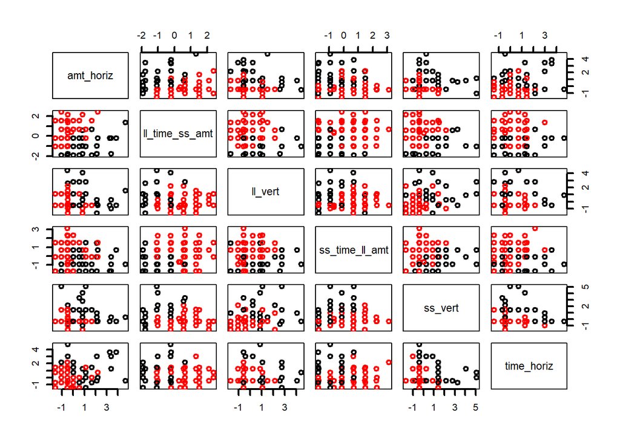

```r
# now run a k means 2 cluster analysis
km_2_cl_first4_6_trans_ht <- kmeans(study2_6trans_first4_z %>%
                               select(-serial, -hard),
                             2, nstart=15)
# take a look at it
plot(study2_6trans_first4_z %>% select(-serial, -hard),
     col= km_2_cl_first4_6_trans_ht$cluster,pch=1,lwd=2 )
```

```r
# merge to get cluster in dataframe
study2_6trans_first4_z <-  study2_6trans_first4_z %>%
  cbind("km_2_cl_first4_6_trans_ht" = km_2_cl_first4_6_trans_ht$cluster)

# look at the table between cluster group and hard transition type
table(study2_6trans_first4_z$hard, study2_6trans_first4_z$km_2_cl_first4_6_trans_ht)
```

```
##
##              1  2
##   hardhoriz 31 68
##   hardvert  35 73
```

```r
chisq.test(study2_6trans_first4_z$hard, study2_6trans_first4_z$km_2_cl_first4_6_trans_ht)
```

```
##
##  Pearson's Chi-squared test with Yates' continuity correction
##
## data:  study2_6trans_first4_z$hard and study2_6trans_first4_z$km_2_cl_first4_6_trans_ht
## X-squared = 0.00037915, df = 1, p-value = 0.9845
```

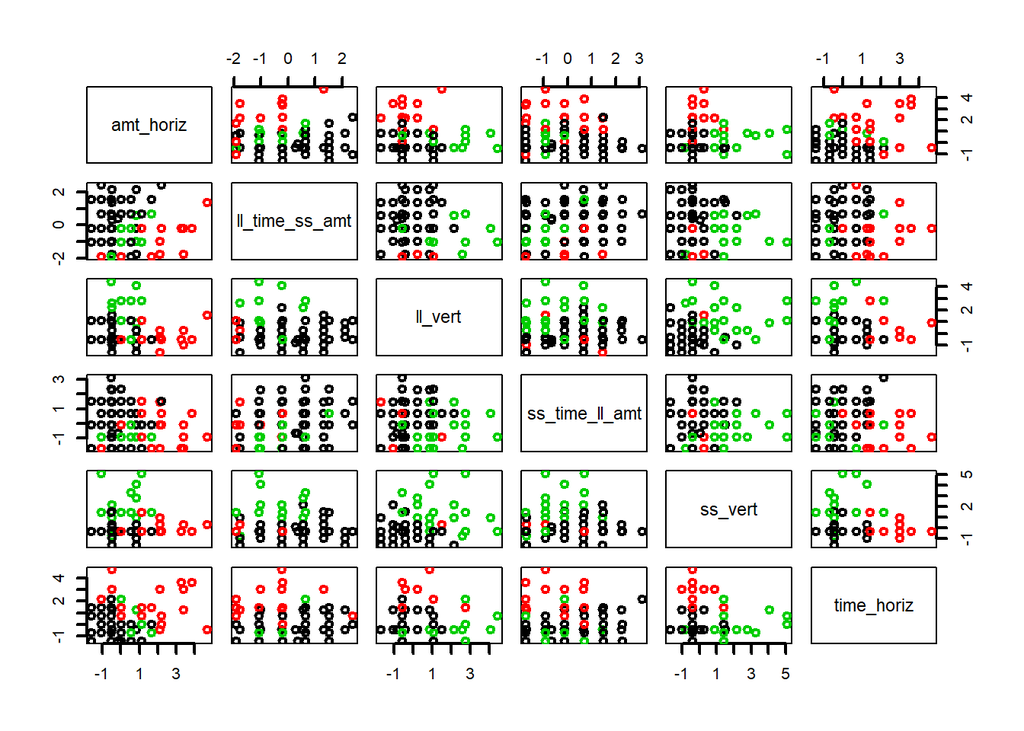

```r
# now with three clusters

# now run a k means 3 cluster analysis
km_3_cl_first4_6_trans_ht <- kmeans(study2_6trans_first4_z %>%
                                      select(-serial, -hard, -starts_with("km")),
                                    3, nstart=15)
# take a look at it
plot(study2_6trans_first4_z %>% select(-serial, -hard, -starts_with("km")),
     col= km_3_cl_first4_6_trans_ht$cluster,pch=1,lwd=2 )
```

```r
# merge to get cluster in dataframe
study2_6trans_first4_z <-  study2_6trans_first4_z %>%
  cbind("km_3_cl_first4_6_trans_ht" = km_3_cl_first4_6_trans_ht$cluster)

# look at the table between cluster group and hard transition type
table(study2_6trans_first4_z$hard, study2_6trans_first4_z$km_3_cl_first4_6_trans_ht)
```

```
##
##              1  2  3
##   hardhoriz 69 12 18
##   hardvert  77 15 16
```

### 2.3.1 Choice Model with BIC

NOTE: THESE MODELS HAVE THE TRIALS WHICH DIDN’T HAVE A BOX OPEN DROPPED

#### 2.3.1.1 2 Cluster model

```r
study2_6trans_first4_z <- study2_6trans_first4_z %>%
                                select(serial, starts_with("km")) %>%
                                  mutate(serial = as.numeric(serial))

study2_payne <- left_join(study2_payne, study2_6trans_first4_z ,
                              by = "serial") %>%
  mutate(km_2_cl_first4_6_trans_ht = factor(km_2_cl_first4_6_trans_ht),
          km_3_cl_first4_6_trans_ht = factor(km_3_cl_first4_6_trans_ht))


ch_2cl_first4_obo <- glmer(choice ~ km_2_cl_first4_6_trans_ht * accel_delay + (1|serial),
                data = study2_payne,
                family = "binomial")

summary(ch_2cl_first4_obo)
```

```
## Generalized linear mixed model fit by maximum likelihood (Laplace
##   Approximation) [glmerMod]
##  Family: binomial  ( logit )
## Formula: choice ~ km_2_cl_first4_6_trans_ht * accel_delay + (1 | serial)
##    Data: study2_payne
##
##      AIC      BIC   logLik deviance df.resid
##   8223.6   8258.0  -4106.8   8213.6     7170
##
## Scaled residuals:
##     Min      1Q  Median      3Q     Max
## -3.6122 -0.7361 -0.2953  0.8325  4.1562
##
## Random effects:
##  Groups Name        Variance Std.Dev.
##  serial (Intercept) 1.983    1.408
## Number of obs: 7175, groups:  serial, 207
##
## Fixed effects:
##                                             Estimate Std. Error z value
## (Intercept)                                 -0.19087    0.18167  -1.051
## km_2_cl_first4_6_trans_ht2                  -0.48571    0.22043  -2.204
## accel_delayDelay                            -0.11747    0.04855  -2.420
## km_2_cl_first4_6_trans_ht2:accel_delayDelay  0.09234    0.05927   1.558
##                                             Pr(>|z|)
## (Intercept)                                   0.2934
## km_2_cl_first4_6_trans_ht2                    0.0276 *
## accel_delayDelay                              0.0155 *
## km_2_cl_first4_6_trans_ht2:accel_delayDelay   0.1192
## ---
## Signif. codes:  0 '***' 0.001 '**' 0.01 '*' 0.05 '.' 0.1 ' ' 1
##
## Correlation of Fixed Effects:
##              (Intr) km_2__4_6__2 accl_D
## km_2__4_6__2 -0.824
## accl_dlyDly   0.002 -0.001
## k_2__4_6__2: -0.001 -0.002       -0.819
```

```r
Anova(ch_2cl_first4_obo)
```

```
## Analysis of Deviance Table (Type II Wald chisquare tests)
##
## Response: choice
##                                        Chisq Df Pr(>Chisq)
## km_2_cl_first4_6_trans_ht             4.8443  1    0.02774 *
## accel_delay                           3.9734  1    0.04622 *
## km_2_cl_first4_6_trans_ht:accel_delay 2.4274  1    0.11923
## ---
## Signif. codes:  0 '***' 0.001 '**' 0.01 '*' 0.05 '.' 0.1 ' ' 1
```

```r
BIC(ch_2cl_first4_obo)
```

```
## [1] 8258.003
```

#### 2.3.1.2 3 cluster model

```r
ch_3cl_first4_obo <- glmer(choice ~ km_3_cl_first4_6_trans_ht * accel_delay + (1|serial),
                data = study2_payne,
                family = "binomial",
                       control=glmerControl(optimizer="bobyqa",
                               optCtrl=list(maxfun=2e5)))

summary(ch_3cl_first4_obo)
```

```
## Generalized linear mixed model fit by maximum likelihood (Laplace
##   Approximation) [glmerMod]
##  Family: binomial  ( logit )
## Formula: choice ~ km_3_cl_first4_6_trans_ht * accel_delay + (1 | serial)
##    Data: study2_payne
## Control:
## glmerControl(optimizer = "bobyqa", optCtrl = list(maxfun = 2e+05))
##
##      AIC      BIC   logLik deviance df.resid
##   8230.0   8278.1  -4108.0   8216.0     7168
##
## Scaled residuals:
##     Min      1Q  Median      3Q     Max
## -3.7067 -0.7458 -0.2996  0.8376  4.1764
##
## Random effects:
##  Groups Name        Variance Std.Dev.
##  serial (Intercept) 1.986    1.409
## Number of obs: 7175, groups:  serial, 207
##
## Fixed effects:
##                                             Estimate Std. Error z value
## (Intercept)                                 -0.63667    0.12294  -5.179
## km_3_cl_first4_6_trans_ht2                   0.62472    0.30831   2.026
## km_3_cl_first4_6_trans_ht3                   0.20561    0.28221   0.729
## accel_delayDelay                            -0.06768    0.03358  -2.015
## km_3_cl_first4_6_trans_ht2:accel_delayDelay  0.01500    0.08151   0.184
## km_3_cl_first4_6_trans_ht3:accel_delayDelay  0.05870    0.07495   0.783
##                                             Pr(>|z|)
## (Intercept)                                 2.23e-07 ***
## km_3_cl_first4_6_trans_ht2                    0.0427 *
## km_3_cl_first4_6_trans_ht3                    0.4663
## accel_delayDelay                              0.0439 *
## km_3_cl_first4_6_trans_ht2:accel_delayDelay   0.8540
## km_3_cl_first4_6_trans_ht3:accel_delayDelay   0.4335
## ---
## Signif. codes:  0 '***' 0.001 '**' 0.01 '*' 0.05 '.' 0.1 ' ' 1
##
## Correlation of Fixed Effects:
##              (Intr) km_3__4_6__2 km_3__4_6__3 accl_D k_3__4_6__2:
## km_3__4_6__2 -0.398
## km_3__4_6__3 -0.435  0.173
## accl_dlyDly  -0.007  0.003        0.003
## k_3__4_6__2:  0.003  0.006       -0.001       -0.412
## k_3__4_6__3:  0.003 -0.001       -0.001       -0.448  0.185
```

```r
Anova(ch_3cl_first4_obo)
```

```
## Analysis of Deviance Table (Type II Wald chisquare tests)
##
## Response: choice
##                                        Chisq Df Pr(>Chisq)
## km_3_cl_first4_6_trans_ht             4.2563  2     0.1191
## accel_delay                           3.9671  1     0.0464 *
## km_3_cl_first4_6_trans_ht:accel_delay 0.6151  2     0.7352
## ---
## Signif. codes:  0 '***' 0.001 '**' 0.01 '*' 0.05 '.' 0.1 ' ' 1
```

```r
BIC(ch_3cl_first4_obo)
```

```
## [1] 8278.128
```

#### 2.3.1.3 All 2 cluster with hard interaction

```r
ch_2cl_first4_allint_obo <- glmer(choice ~ km_2_cl_first4_6_trans_ht * accel_delay  * hard+ (1|serial),
                data = study2_payne,
                family = "binomial",
                         control=glmerControl(optimizer="bobyqa",
                                              optCtrl=list(maxfun=2e5)))

summary(ch_2cl_first4_allint_obo)
```

```
## Generalized linear mixed model fit by maximum likelihood (Laplace
##   Approximation) [glmerMod]
##  Family: binomial  ( logit )
## Formula: choice ~ km_2_cl_first4_6_trans_ht * accel_delay * hard + (1 |
##     serial)
##    Data: study2_payne
## Control:
## glmerControl(optimizer = "bobyqa", optCtrl = list(maxfun = 2e+05))
##
##      AIC      BIC   logLik deviance df.resid
##   8226.2   8288.1  -4104.1   8208.2     7166
##
## Scaled residuals:
##     Min      1Q  Median      3Q     Max
## -3.6109 -0.7369 -0.2981  0.8343  4.1292
##
## Random effects:
##  Groups Name        Variance Std.Dev.
##  serial (Intercept) 1.922    1.386
## Number of obs: 7175, groups:  serial, 207
##
## Fixed effects:
##                                                           Estimate
## (Intercept)                                              -0.545536
## km_2_cl_first4_6_trans_ht2                               -0.307573
## accel_delayDelay                                         -0.118792
## hardhardvert                                              0.664726
## km_2_cl_first4_6_trans_ht2:accel_delayDelay               0.079551
## km_2_cl_first4_6_trans_ht2:hardhardvert                  -0.322301
## accel_delayDelay:hardhardvert                             0.004135
## km_2_cl_first4_6_trans_ht2:accel_delayDelay:hardhardvert  0.022310
##                                                          Std. Error
## (Intercept)                                                0.262573
## km_2_cl_first4_6_trans_ht2                                 0.317027
## accel_delayDelay                                           0.071481
## hardhardvert                                               0.358955
## km_2_cl_first4_6_trans_ht2:accel_delayDelay                0.086799
## km_2_cl_first4_6_trans_ht2:hardhardvert                    0.435259
## accel_delayDelay:hardhardvert                              0.097429
## km_2_cl_first4_6_trans_ht2:accel_delayDelay:hardhardvert   0.118828
```

[output cut: 23 more lines]

```
## km_2__4_6__2    -0.828
## accl_dlyDly     -0.008  0.007
## hardhardvrt     -0.731  0.605        0.006
## km_2__4_6__2:_D  0.006 -0.006       -0.824 -0.005
## km_2__4_6__2:    0.603 -0.728       -0.005 -0.824  0.004
## accl_dlyDl:      0.006 -0.005       -0.734  0.000  0.604
## k_2__4_6__2:_D: -0.005  0.004        0.601  0.000 -0.730
##                 km_2__4_6__2: acc_D:
## km_2__4_6__2
## accl_dlyDly
## hardhardvrt
## km_2__4_6__2:_D
## km_2__4_6__2:
## accl_dlyDl:      0.000
## k_2__4_6__2:_D: -0.002        -0.820
```

```r
Anova(ch_2cl_first4_allint_obo)
```

```
## Analysis of Deviance Table (Type II Wald chisquare tests)
##
## Response: choice
##                                             Chisq Df Pr(>Chisq)
## km_2_cl_first4_6_trans_ht                  4.8384  1    0.02783 *
## accel_delay                                3.9511  1    0.04684 *
## hard                                       4.8215  1    0.02811 *
## km_2_cl_first4_6_trans_ht:accel_delay      2.3794  1    0.12295
## km_2_cl_first4_6_trans_ht:hard             0.5478  1    0.45924
## accel_delay:hard                           0.1176  1    0.73160
## km_2_cl_first4_6_trans_ht:accel_delay:hard 0.0352  1    0.85107
## ---
## Signif. codes:  0 '***' 0.001 '**' 0.01 '*' 0.05 '.' 0.1 ' ' 1
```

```r
BIC(ch_2cl_first4_allint_obo)
```

```
## [1] 8288.086
```

## 2.4 Adopting the Encouraged Strategy

### 2.4.1 Demographics

Importantly, there were no observed differences in the demographics or any individual difference measures collected between the participants removed and those retained (all pâs > .1).

```r
study2_payne_compl <- study2_payne %>%
  group_by(serial) %>%
  filter(!(is.na(compliance_ind))) %>%
  mutate(n_noncomp = sum(compliance_ind != 1, na.rm = TRUE),
         n_q = n(),
         serial_compliance = ifelse(n_noncomp == n_q,
                                    "non_complier",
                                    "complier"))
hard_comp <- study2_payne_compl %>%
  group_by(serial) %>%
  sample_n(1)

chisq.test(hard_comp$hard, hard_comp$serial_compliance)
```

```
##
##  Pearson's Chi-squared test with Yates' continuity correction
##
## data:  hard_comp$hard and hard_comp$serial_compliance
## X-squared = 1.0649e-30, df = 1, p-value = 1
```

```r
hard_comp <- hard_comp %>%
  ungroup %>%
  mutate(serial = as.numeric(serial))
study2_info <- study2_info %>%
  mutate(serial = as.numeric(serial))

hard_comp_mer <- left_join(hard_comp, study2_info) %>%
  ungroup() %>%
  mutate(n_nocomp = sum(serial_compliance == "non_complier"),
         n_comp = sum(serial_compliance == "complier"))
```

```r
# demographics that aren't age
demo_hard_comp <- hard_comp_mer %>%
  select(serial, hard, n_nocomp, n_comp, serial_compliance, belief_pay:confusing) %>%
  select(-birthyear, - birthmonth, -think_study, - what_unus, - guess_open, -reader) %>%
  melt(id = c("serial", "hard", "n_nocomp", "n_comp", "serial_compliance")) %>%
  group_by(variable, value,n_nocomp, n_comp, serial_compliance) %>%
  summarise(n_level = n()) %>%
  dcast(variable + n_nocomp + n_comp +value ~ serial_compliance, value.var = "n_level")
demo_hard_comp[is.na(demo_hard_comp)] <- 0


demo_hard_comp %>%
  filter(variable !="occupation_other") %>%
  dplyr::group_by(variable) %>%
  do(broom::tidy(chisq.test(x = .$complier,
                            y = .$non_complier))) %>%
  mutate(p.value = round(p.value, 2)) %>%
  arrange(p.value)
```

[output not shown]

[output cut: 31 more lines]

[output not shown]

[output not shown]

```
## # A tibble: 30 x 5
## # Groups:   variable [30]
##               variable statistic p.value parameter
##                 <fctr>     <dbl>   <dbl>     <int>
##  1             marital        28    0.11        20
##  2            children        21    0.14        15
##  3          ease_acq_1        24    0.16        18
##  4          employment        40    0.16        32
##  5          belief_pay         6    0.20         4
##  6   selected_received         6    0.20         4
##  7    selected_delayed         6    0.20         4
##  8 experimenter_choose         6    0.20         4
##  9             unusual         6    0.20         4
## 10              gender         6    0.20         4
## # ... with 20 more rows, and 1 more variables: method <chr>
```

Percentage of transitions that avoid the manipulation across each trial in the task. The fit line indicates a locally weighted scatter plot smooth. Such transitions were more common early in the task

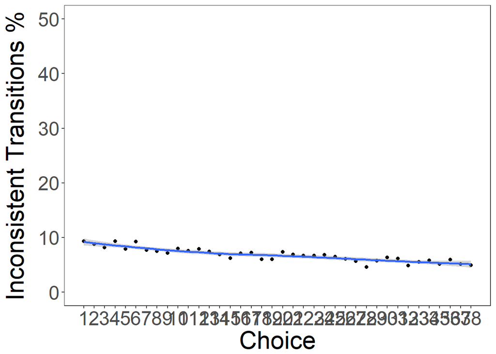

```r
per_avoid_per_item <- study2_nothresh_trans %>%
  group_by(serial, tot_no_choice) %>%
  summarise(n_trans_sum = sum(n_trans, na.rm = TRUE),
            n_loophole_sum = n_loophole[1]) %>%
  ungroup %>%
  mutate(n_loophole_sum = case_when(is.na(n_loophole_sum) ~ 0L,
                                    !is.na(n_loophole_sum) ~ n_loophole_sum),
         per_loophole = (n_loophole_sum/n_trans_sum)*100) %>%
  group_by(tot_no_choice) %>%
  summarise(mean_per_loophole = mean(per_loophole))

(per_avoid_per_item_p <- ggplot(per_avoid_per_item, aes(x = tot_no_choice, y = mean_per_loophole)) +
  geom_point() +
  geom_smooth() +
  scale_x_continuous(name = "Choice", breaks = 1:38) +
  scale_y_continuous(name = "Inconsistent Transitions %", limits = c(0, 50)) +
    theme_bw() +
  theme(panel.grid.major = element_blank(),
        panel.grid.minor = element_blank(),
        legend.key = element_blank(),
        text = element_text(size=25),
        axis.title.y=element_text(margin=margin(0,15,0,0))))
```

```r
tiff("/Users/Dan/Dropbox/MLWeb/Paper Figures/FigureSXPercentAvoidTrans.tif", res = 300, width = 4500, height = 2000)
per_avoid_per_item_p # Make plot
dev.off()
```